# Clustering Homework

```r
library(tidyverse)
library(janitor)
library(here)
library(factoextra)
library(broom)
```

# EDA

Mall data is a dataframe with 5 columns and 200 rows. All Columns are `double` apart from gender which is `character`, will probably change to factor or logical. No NA’s are present in the data. the Columns are:

1. customer_id
2. gender
3. age
4. annual_income_k
5. spending_score_1_100 - presumming score is from 1 to 100.

Max annual income appears to be 137k, max spending score is 99.

```r
# read in data and explore

mall <- read_csv(here('data/mall_customers.csv')) %>%
  clean_names()
head(mall)
```

| customer_id | gender | age | annual_income_k | spending_score_1_100 |
| --- | --- | --- | --- | --- |
| 1 | Male | 19 | 15 | 39 |
| 2 | Male | 21 | 15 | 81 |
| 3 | Female | 20 | 16 | 6 |
| 4 | Female | 23 | 16 | 77 |
| 5 | Female | 31 | 17 | 40 |
| 6 | Female | 22 | 17 | 76 |

```r
glimpse(mall)
```

```
Rows: 200
Columns: 5
$ customer_id          <dbl> 1, 2, 3, 4, 5, 6, 7, 8, 9, 10, 11, 12, 13, 14, 15, 16, 17, 18, 19, 20, 21, 22, 23, 24, 2…
$ gender               <chr> "Male", "Male", "Female", "Female", "Female", "Female", "Female", "Female", "Male", "Fem…
$ age                  <dbl> 19, 21, 20, 23, 31, 22, 35, 23, 64, 30, 67, 35, 58, 24, 37, 22, 35, 20, 52, 35, 35, 25, …
$ annual_income_k      <dbl> 15, 15, 16, 16, 17, 17, 18, 18, 19, 19, 19, 19, 20, 20, 20, 20, 21, 21, 23, 23, 24, 24, …
$ spending_score_1_100 <dbl> 39, 81, 6, 77, 40, 76, 6, 94, 3, 72, 14, 99, 15, 77, 13, 79, 35, 66, 29, 98, 35, 73, 5, …
```

```r
mall %>%
  summarise(across(everything(), .fns = ~sum(is.na(.x))))
```

| customer_id | gender | age | annual_income_k | spending_score_1_100 |
| --- | --- | --- | --- | --- |
| 0 | 0 | 0 | 0 | 0 |

```r
slice_max(mall, annual_income_k)
```

| customer_id | gender | age | annual_income_k | spending_score_1_100 |
| --- | --- | --- | --- | --- |
| 199 | Male | 32 | 137 | 18 |
| 200 | Male | 30 | 137 | 83 |

```r
slice_max(mall, spending_score_1_100)
```

| customer_id | gender | age | annual_income_k | spending_score_1_100 |
| --- | --- | --- | --- | --- |
| 12 | Female | 35 | 19 | 99 |

```r
NA
```

```r
# selecting columns to cluster
mall_trim <- mall %>%
  select(-age, -gender, -customer_id)
mall_trim
```

| annual_income_k | spending_score_1_100 |
| --- | --- |
| 15 | 39 |
| 15 | 81 |
| 16 | 6 |
| 16 | 77 |
| 17 | 40 |
| 17 | 76 |
| 18 | 6 |
| 18 | 94 |
| 19 | 3 |
| 19 | 72 |

[output cut: 190 more lines]

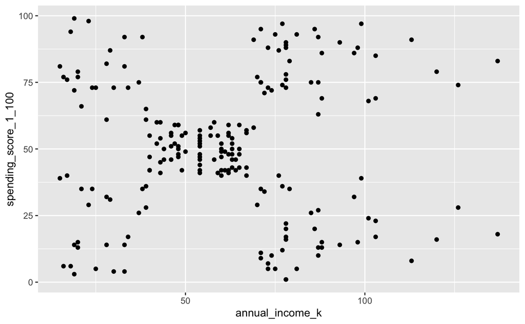

```r
# quick plot to see how the data looks
ggplot(mall_trim, aes(x = annual_income_k, y = spending_score_1_100)) +
  geom_point()
```

```r
# scaling data
mall_scale <- mall_trim %>%
  select(-customer_id) %>%
  mutate(across(where(is.numeric), scale))
mall_scale
```

| annual_income_k | spending_score_1_100 |
| --- | --- |
| -1.73464625 | -0.433713114 |
| -1.73464625 | 1.192711064 |
| -1.69657236 | -1.711617825 |
| -1.69657236 | 1.037813523 |
| -1.65849848 | -0.394988729 |
| -1.65849848 | 0.999089138 |
| -1.62042459 | -1.711617825 |
| -1.62042459 | 1.696128071 |
| -1.58235070 | -1.827790981 |
| -1.58235070 | 0.844191597 |

[output cut: 190 more lines]

```r
mall_scale %>%
  as_tibble() %>%
  pivot_longer(cols = c(annual_income_k, spending_score_1_100),
               names_to = "type",
               values_to = "value") %>%
  group_by(type) %>%
  summarise(mean = round(mean(value)),
            sd = sd(value))
```

| type | mean | sd |
| --- | --- | --- |
| annual_income_k | 0 | 1 |
| spending_score_1_100 | 0 | 1 |

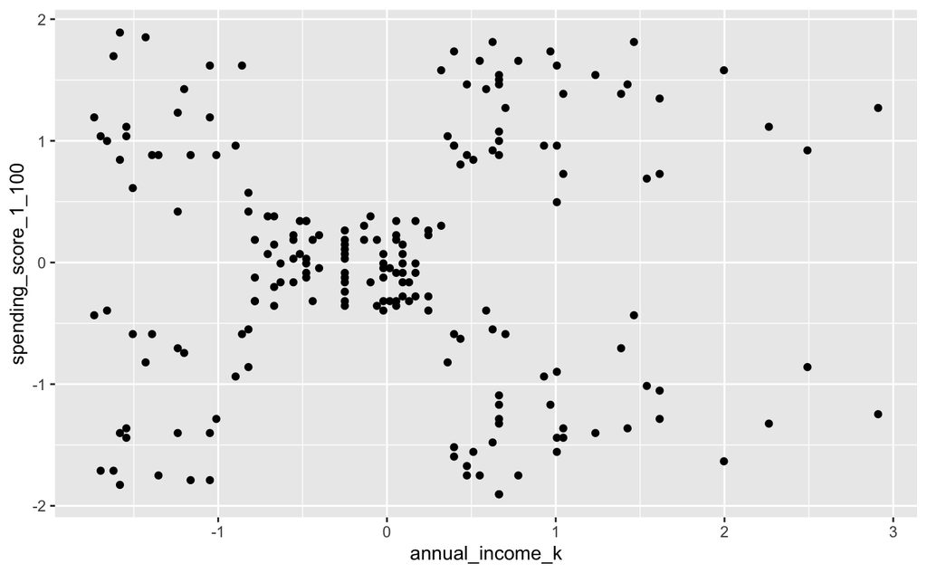

```r
# check the plot after scaling, looks the same
ggplot(mall_scale, aes(x = annual_income_k, y = spending_score_1_100)) +
  geom_point()
```

# Clustering

Try a few methods to see how the data clusters. Looks like five cluster groups is a good way forward.

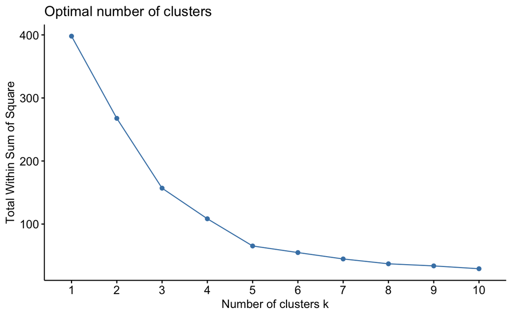

```r
# Elbow method
fviz_nbclust(mall_scale,
             kmeans,
             method = "wss",
             nstart = 25)
```

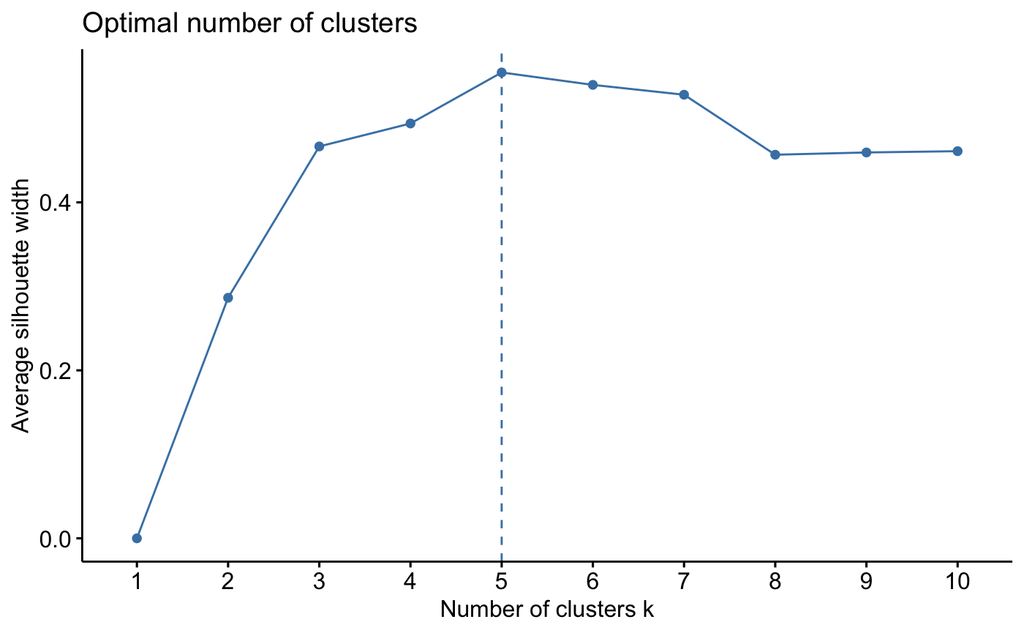

```r
# silhouette method
fviz_nbclust(mall_scale,
             kmeans,
             method = "silhouette",
             nstart = 25)
```

```
Clustering k = 1,2,..., K.max (= 10): .. done
Bootstrapping, b = 1,2,..., B (= 100)  [one "." per sample]:
.................................................. 50
.................................................. 100
```

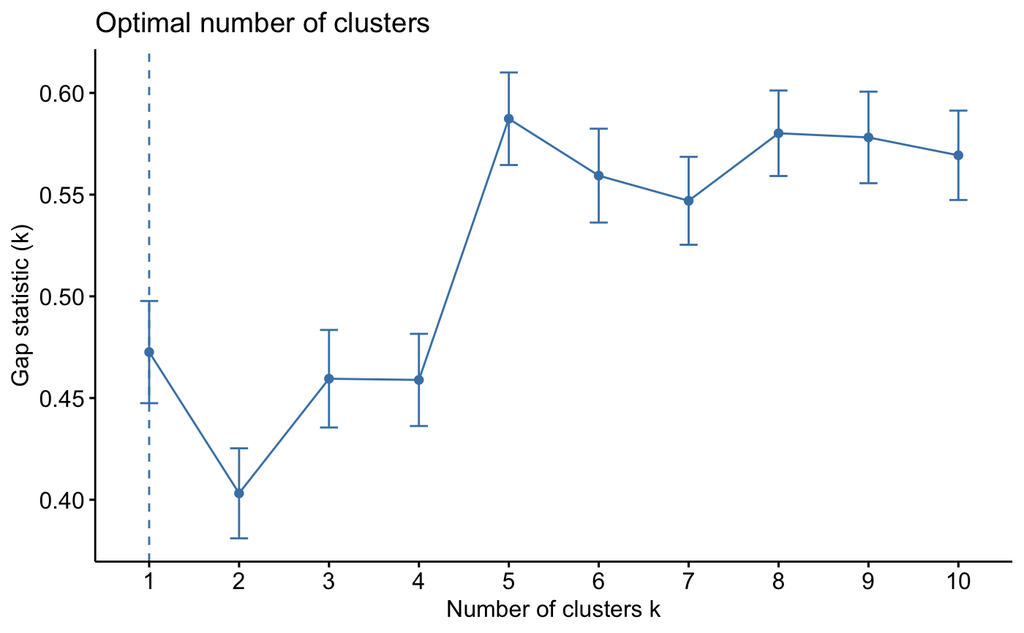

```r
# gap_stat method, not sure how to interpret this!
fviz_nbclust(mall_scale,
             kmeans,
             method = "gap_stat",
             nstart=25)
```

## Set up clustering

```r
# kmeans to set up 5 clusters
clustered_mall_scale <- kmeans(mall_scale, 5, nstart = 25)

clustered_mall <- kmeans(mall_trim, 5, nstart = 25)
```

```r
# cluster sizes
clustered_mall_scale$size
```

```
[1] 39 81 22 23 35
```

```r
# cluster centres
clustered_mall_scale$centers
```

```
  annual_income_k spending_score_1_100
1       0.9891010           1.23640011
2      -0.2004097          -0.02638995
3      -1.3262173           1.12934389
4      -1.3042458          -1.13411939
5       1.0523622          -1.28122394
```

## Visualise the clusters

[figure not shown]

```r
clusters <- augment(clustered_mall_scale, mall_scale)

ggplot(clusters, aes(annual_income_k, spending_score_1_100, colour = .cluster)) +
  geom_point()
```

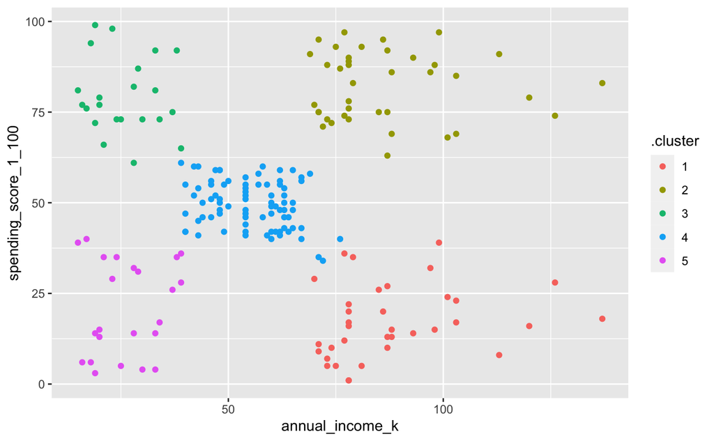

```r
# plotting non scaled data
clusters_non_scaled <- augment(clustered_mall, mall_trim)

ggplot(clusters_non_scaled, aes(annual_income_k, spending_score_1_100, colour = .cluster)) +
  geom_point()
```

Non scaled data changes the clusters slightly, but is easier to interpret.

```r
# looking at averages of income and spending score by cluster
clusters_non_scaled %>%
  group_by(.cluster) %>%
  summarise(annual_income_k = mean(annual_income_k), spending_score_1_100 = mean(spending_score_1_100)) %>%
  arrange(desc(spending_score_1_100))
```

| .cluster | annual_income_k | spending_score_1_100 |
| --- | --- | --- |
| 2 | 86.53846 | 82.12821 |
| 3 | 25.72727 | 79.36364 |
| 4 | 55.29630 | 49.51852 |
| 5 | 26.30435 | 20.91304 |
| 1 | 88.20000 | 17.11429 |

```r
NA
```

# Comments on clusters and Targeting

After initial exploration I settled on building 5 clusters with the data. Once K-means clustering was completed we are left with 5 clusters as summarised above. The results are interesting from a targeting point of view.

The two highest average earners, clusters 1 and 2, are separated by around 2k in earnings but the spending scores are very different, with the cluster that earns slightly less (2) scoring significantly higher. Cluster 2 actually has the highest average spending score (82) in the dataset. I would suggest targeting this cluster in the first instance.

Overall in terms of targeting based on spending score I would go for the following order: 2, 3, 4, 5, 1.